# FDR calibration: `fs-effMaxSG` with `selection_rule = "both"`

- Show All Code
- Hide All Code
- View Source

Null-DGM false-discovery rate vs the screening / consistency effect thresholds (ACTG175 binary, OR scale)

Author

forestsearch v0.2.0

Published

June 5, 2026

## 1 Purpose

This study calibrates the **false-discovery rate (FDR)** of the consistency engine under `sg_focus = "effMaxSG"` and `selection_rule = "both"` — the `fs-effMaxSG` arm of the ACTG175 binary multi-method study — by sweeping the **screening effect threshold** and the **per-split consistency threshold**.

`fs-effMaxSG/both` declares a harm subgroup only when a candidate (i) clears the screening floor `effect.threshold` (an odds ratio), and (ii) is *consistent*: its effect exceeds `consistency.threshold` in at least `pconsistency.threshold` of the bootstrap splits, and the candidate survives the `"both"` inclusion band (effect-neighborhood **and** Pareto frontier). Under a **null** data-generating model — homogeneous treatment effect, no true harm subgroup — *any* declared subgroup is a false discovery. So, under the null,

$$\text{FDR} \;=\; \Pr(\text{declare a harm subgroup} \mid \text{null})
\;=\; \mathbb{E}\!\left[\texttt{any.H}\right].$$

**Why only the null.** FDR depends only on the null regime; the alternative (“power”) regime is the costlier half of a full operating-characteristic study and is not needed here. This document runs the null DGM only.

**What is swept.** The two effect-magnitude thresholds are the drivers (the consistency *rate* `pconsistency.threshold` is held fixed at a defensible 0.90 — nothing below 0.7 would be reassuring as a notion of “consistency”):

- `effect.threshold` over `seq(1, 2, 0.25)` (OR scale: 1.00, 1.25, 1.50, 1.75, 2.00);
- `consistency.threshold = k * effect.threshold`, for `k in {0.8, 1.0}`.

The output is FDR vs `effect.threshold`, by `k` and `n`, plus the smallest `effect.threshold` (per `k`, `n`) that brings FDR at or below the target.

> **Runtime note.** Unlike a GRF sweep, each cell here runs the full consistency search (bootstrap splits), so the grid is heavy: `length(n) * length(eff) * length(k) * nsims` fits. Start with a small `nsims` (e.g. 25–50) in `CONFIG` to smoke-test the pipeline, then scale up.

## 2 Setup

```r
library(forestsearch)
library(speff2trial)
library(data.table)
library(ggplot2)
library(future)
library(foreach)
library(doFuture)

registerDoFuture()

# Resolve the fs-params bundle whether rendering from the package root or a
# quarto/<subdir>/ location.
.fs_tag    <- "fs3"
.fs_cands  <- c(sprintf("_fsparams/%s_params.R", .fs_tag),
                sprintf("../_fsparams/%s_params.R", .fs_tag),
                sprintf("../../_fsparams/%s_params.R", .fs_tag))
.fs_path   <- .fs_cands[file.exists(.fs_cands)][1L]
if (is.na(.fs_path)) stop("Could not locate _fsparams/", .fs_tag, "_params.R")
source(.fs_path)

CONFIG <- list(
  # Monte Carlo
  nsims      = 500L,                         # replications per (n, eff, k) cell
  seed_base  = 8316951L,                     # run_simulation_analysis: data seed = seed_base + sim

  # Design grid
  n_levels   = c(700L, 1400L),               # sim_n (ACTG175 arm sizes) and 2x to expose n-drift
  effect_threshold_grid = seq(1.0, 2.0, by = 0.25),  # screening OR floor (the sweep)
  k_grid     = c(0.8, 1.0),                  # consistency.threshold = k * effect.threshold

  # Held fixed (effect/consistency thresholds are the drivers; see Purpose)
  pconsistency        = 0.90,                # consistency rate (>= 0.7 only)
  sg_focus            = "effMaxSG",
  selection_rule      = "both",
  effect_neighborhood = 0.10,

  # Calibration target
  target_fdr = 0.10,

  # Parallel (outer MC loop; the inner forestsearch run stays SEQUENTIAL to
  # avoid nested-parallelism collapse)
  workers    = floor(0.95 * max(1L, parallel::detectCores(logical = FALSE))),
  plan       = "multisession"
)

# fs base params: the canonical fs3 bundle, focus = effMaxSG.  Per-cell the
# thresholds below are overridden in fit_and_score(); everything else (id /
# treat / outcome names, confounder forcing, continuous cut counts, fs.splits,
# is.RCT, etc.) is inherited from the bundle so the arm matches the vignette.
fs_params <- get(sprintf("get_%s_params", .fs_tag))(sg_focus = CONFIG$sg_focus)

# Single-arm spec: fs-effMaxSG, consistency engine, selection_rule = "both".
# Mirrors make_methods()'s fs branch (subgroup_method, sg_focus, selection_rule,
# dmin.grf screening floor) exactly.
fs_spec <- list(
  "fs-effMaxSG" = list(
    subgroup_method = "consistency",
    sg_focus        = "effMaxSG",
    selection_rule  = "both",
    dmin.grf        = 0.0
  )
)
```

## 3 ACTG175 data and null DGM

Reproduces the vignette’s data preparation and builds the **null** GLM DGM (`model = "null"`: homogeneous effect, no harm subgroup) on the same covariates.

**ACTG175 data prep + null DGM (click to expand)**

```r
# ACTG175: arm 1 = ZDV+ddI (experimental), arm 3 = ddI (control)
actg_df <- subset(speff2trial::ACTG175, arms %in% c(1L, 3L))
actg_df$id <- seq_len(nrow(actg_df))

# Treatment: ZDV+ddI = 1, ddI = 0 (NO switching)
actg_df$treat <- ifelse(actg_df$arms == 1L, 1L, 0L)

# Binary outcome: adverse (failure to improve)
actg_df$y_binary <- as.integer(actg_df$cd420 <= actg_df$cd40)
actg_df <- actg_df[!is.na(actg_df$cd420), ]

# -- DGM factor variables -----------------------------------------------------
actg_df$z1  <- as.factor(ifelse(actg_df$cd40 > 390, 1L, 0L))
actg_df$z2  <- as.factor(ifelse(actg_df$wtkg > 80, 1L, 0L))

# z7-z12: truly binary indicators (no continuous counterpart)
actg_df$z7  <- as.factor(actg_df$hemo)
actg_df$z8  <- as.factor(actg_df$homo)
actg_df$z9  <- as.factor(actg_df$drugs)
actg_df$z10 <- as.factor(actg_df$race)
actg_df$z11 <- as.factor(actg_df$gender)
actg_df$z12 <- as.factor(actg_df$symptom)

actg_df$ar_naive   <- as.integer(ifelse(actg_df$str2 == 0, 1L, 0L))
actg_df$prior_6mo  <- as.integer(ifelse(actg_df$preanti <= 6 * 30.4375, 1L, 0L))

actg_df$flag_harm_ref <- as.integer(actg_df$z1 == 1 & actg_df$z2 == 1)

# -- Analysis covariates (what the analyst sees) -------------------------------
cont_vars <- c("age", "preanti", "wtkg", "karnof", "cd40", "cd80")
bin_vars  <- c("hemo", "homo", "drugs", "race", "gender", "symptom", "ar_naive", "prior_6mo")
for (v in bin_vars) actg_df[[v]] <- as.integer(actg_df[[v]])
confounders <- c(cont_vars, bin_vars)

# -- DGM variable sets ---------------------------------------------------------
dgm_factor_vars   <- c("z1", "z2", paste0("z", 7:12))
dgm_cont_vars     <- cont_vars
dgm_subgroup_vars <- c("z1", "z2")
dgm_subgroup_cuts <- list(z1 = 1L, z2 = 1L)

# -- Null DGM (homogeneous effect; no harm subgroup) ---------------------------
dgm_null <- generate_glm_dgm(
  data            = actg_df,
  factor_vars     = dgm_factor_vars,
  continuous_vars = dgm_cont_vars,
  outcome_var     = "y_binary",
  treatment_var   = "treat",
  outcome_type    = "binary",
  subgroup_vars   = dgm_subgroup_vars,
  subgroup_cuts   = dgm_subgroup_cuts,
  model           = "null",
  n_super         = 5000L,
  seed            = 8316951L,
  verbose         = FALSE
)

# Carry the run-time objects into CONFIG so the worker closure is self-contained.
CONFIG$fs_params   <- fs_params
CONFIG$fs_spec     <- fs_spec
CONFIG$dgm_null    <- dgm_null
CONFIG$confounders <- confounders

cat(sprintf("Null DGM built on N = %d ACTG175 subjects; confounders = %d.\n",
            nrow(actg_df), length(confounders)))
```

```
Null DGM built on N = 1083 ACTG175 subjects; confounders = 14.
```

## 4 One run: fit `fs-effMaxSG/both` at a given `(effect_threshold, k)`, score detection

Each call runs the arm through `run_simulation_analysis()` — the same code path the vignette uses — and reads the per-method detection flag `any.H`. Under the null, `any.H == TRUE` is a false discovery. Because `run_simulation_analysis()` seeds the data generation as `seed_base + sim_id` (independent of `fs_params`), reusing `sim_id` across the threshold grid means a given `(n, sim)` cell is evaluated on the **same** null dataset at every `(effect_threshold, k)` — a paired design that sharpens the FDR curves.

```r
fit_and_score <- function(eff_thr, k, n, sim, cfg) {
  fp <- cfg$fs_params
  # the swept thresholds (set both the preferred names and the hr.* aliases)
  fp$effect.threshold       <- eff_thr
  fp$hr.threshold           <- eff_thr
  fp$consistency.threshold  <- k * eff_thr
  fp$hr.consistency         <- k * eff_thr
  fp$pconsistency.threshold <- cfg$pconsistency
  fp$selection_rule         <- cfg$selection_rule
  fp$effect_neighborhood    <- cfg$effect_neighborhood
  # critical: keep the inner forestsearch run sequential inside %dofuture%
  fp$parallel_args$plan     <- "sequential"
  fp$parallel_args$workers  <- 1L

  res <- tryCatch(
    run_simulation_analysis(
      sim_id           = sim,
      dgm              = cfg$dgm_null,
      n_sample         = n,
      confounders_base = cfg$confounders,
      methods          = cfg$fs_spec,
      fs_params        = fp,
      seed_base        = cfg$seed_base,
      verbose          = FALSE
    ),
    error = function(e) NULL)

  if (is.null(res) || nrow(res) == 0L) {
    return(data.table(found = NA, err = TRUE))
  }
  anyH <- if ("any.H" %in% names(res))
            suppressWarnings(as.logical(res$any.H[1L])) else NA
  data.table(found = isTRUE(anyH), err = FALSE)
}
```

## 5 Sweep: `n` x `effect_threshold` x `k` (null only)

```r
future::plan(CONFIG$plan, workers = CONFIG$workers)
on.exit({ future::plan("sequential"); gc(verbose = FALSE) }, add = TRUE)

grid <- CJ(n   = CONFIG$n_levels,
           eff = CONFIG$effect_threshold_grid,
           k   = CONFIG$k_grid,
           sim = seq_len(CONFIG$nsims))

.t0 <- proc.time()[["elapsed"]]
res_rows <- foreach(
  i = seq_len(nrow(grid)),
  .combine = rbind,
  .options.future = list(
    seed     = TRUE,
    packages = c("forestsearch", "data.table", "future")
  )
) %dofuture% {
  future::plan("sequential")
  row <- grid[i]
  out <- fit_and_score(row$eff, row$k, row$n, row$sim, CONFIG)
  cbind(row[, .(n, eff, k, sim)], out)
}
total_wall_sec <- proc.time()[["elapsed"]] - .t0
future::plan("sequential"); gc(verbose = FALSE)
```

```
          used  (Mb) gc trigger  (Mb) limit (Mb) max used  (Mb)
Ncells 2603251 139.1    6094865 325.6         NA  6094865 325.6
Vcells 4937364  37.7   43627527 332.9      36864 54534408 416.1
```

```r
res <- as.data.table(res_rows)
```

## 6 Wall-clock timing

```r
data.table(
  n_cells       = nrow(grid),
  nsims         = CONFIG$nsims,
  wall_min      = round(total_wall_sec / 60, 2),
  wall_hr       = round(total_wall_sec / 3600, 3),
  failed_runs   = res[, sum(err, na.rm = TRUE)]
)
```

| n_cells | nsims | wall_min | wall_hr | failed_runs |
| --- | --- | --- | --- | --- |
| 10000 | 500 | 1117.43 | 18.624 | 0 |

## 7 FDR table (per cell)

`found_rate` is the false-discovery rate: the fraction of null replicates in which `fs-effMaxSG/both` declared a harm subgroup. `fdr_se` is the binomial standard error over the successful replications.

```r
agg <- res[, {
  m <- sum(!is.na(found))
  p <- mean(found, na.rm = TRUE)
  .(n_ok   = m,
    n_fail = sum(is.na(found)),
    fdr    = p,
    fdr_se = if (m > 0L) sqrt(p * (1 - p) / m) else NA_real_)
}, by = .(n, k, eff)][order(n, k, eff)]

knitr::kable(
  agg[, .(n, k, eff,
          fdr    = round(fdr, 3),
          fdr_se = round(fdr_se, 3),
          n_ok, n_fail)],
  col.names = c("n", "k", "effect.threshold", "FDR", "SE", "n (ok)", "n (fail)"),
  caption = sprintf(
    "Null-DGM false-discovery rate for fs-effMaxSG/both over %d replications per cell (pconsistency = %.2f).",
    CONFIG$nsims, CONFIG$pconsistency))
```

Null-DGM false-discovery rate for fs-effMaxSG/both over 500 replications per cell (pconsistency = 0.90).

| n | k | effect.threshold | FDR | SE | n (ok) | n (fail) |
| --- | --- | --- | --- | --- | --- | --- |
| 700 | 0.8 | 1.00 | 0.886 | 0.014 | 500 | 0 |
| 700 | 0.8 | 1.25 | 0.612 | 0.022 | 500 | 0 |
| 700 | 0.8 | 1.50 | 0.302 | 0.021 | 500 | 0 |
| 700 | 0.8 | 1.75 | 0.136 | 0.015 | 500 | 0 |
| 700 | 0.8 | 2.00 | 0.066 | 0.011 | 500 | 0 |
| 700 | 1.0 | 1.00 | 0.614 | 0.022 | 500 | 0 |
| 700 | 1.0 | 1.25 | 0.268 | 0.020 | 500 | 0 |
| 700 | 1.0 | 1.50 | 0.088 | 0.013 | 500 | 0 |
| 700 | 1.0 | 1.75 | 0.036 | 0.008 | 500 | 0 |
| 700 | 1.0 | 2.00 | 0.014 | 0.005 | 500 | 0 |
| 1400 | 0.8 | 1.00 | 0.780 | 0.019 | 500 | 0 |
| 1400 | 0.8 | 1.25 | 0.400 | 0.022 | 500 | 0 |
| 1400 | 0.8 | 1.50 | 0.142 | 0.016 | 500 | 0 |
| 1400 | 0.8 | 1.75 | 0.026 | 0.007 | 500 | 0 |
| 1400 | 0.8 | 2.00 | 0.006 | 0.003 | 500 | 0 |
| 1400 | 1.0 | 1.00 | 0.398 | 0.022 | 500 | 0 |
| 1400 | 1.0 | 1.25 | 0.098 | 0.013 | 500 | 0 |
| 1400 | 1.0 | 1.50 | 0.010 | 0.004 | 500 | 0 |
| 1400 | 1.0 | 1.75 | 0.004 | 0.003 | 500 | 0 |
| 1400 | 1.0 | 2.00 | 0.000 | 0.000 | 500 | 0 |

## 8 False-discovery-rate curve

FDR vs the screening `effect.threshold`, by the consistency multiplier `k` and sample size `n`. Dotted lines mark the 0.05 / 0.10 targets; error bars are +/- 1 binomial SE.

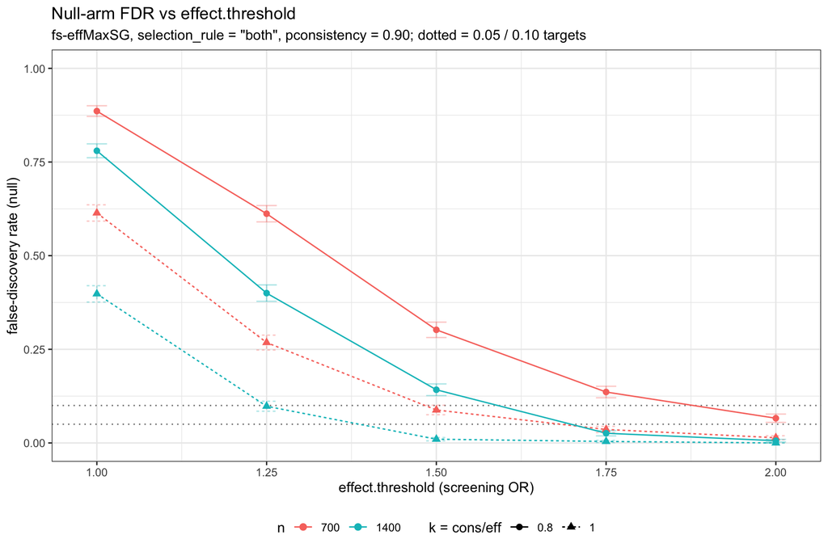

```r
ggplot(agg, aes(x = eff, y = fdr,
                colour = factor(n), linetype = factor(k), shape = factor(k))) +
  geom_hline(yintercept = c(0.05, 0.10), linetype = "dotted", colour = "grey50") +
  geom_errorbar(aes(ymin = pmax(0, fdr - fdr_se), ymax = pmin(1, fdr + fdr_se)),
                width = 0.03, alpha = 0.35) +
  geom_line() +
  geom_point(size = 2.1) +
  scale_y_continuous(limits = c(0, 1)) +
  scale_x_continuous(breaks = CONFIG$effect_threshold_grid) +
  labs(x = "effect.threshold (screening OR)",
       y = "false-discovery rate (null)",
       colour = "n", linetype = "k = cons/eff", shape = "k = cons/eff",
       title = "Null-arm FDR vs effect.threshold",
       subtitle = sprintf(
         "fs-effMaxSG, selection_rule = \"both\", pconsistency = %.2f; dotted = 0.05 / 0.10 targets",
         CONFIG$pconsistency)) +
  theme_bw() + theme(legend.position = "bottom")
```

## 9 Calibrated threshold

For each `(n, k)`, the smallest `effect.threshold` on the grid that brings the null FDR at or below the target, with the FDR achieved there.

```r
target_fdr <- CONFIG$target_fdr
calib <- agg[fdr <= target_fdr][order(eff),
              .(eff_star = eff[1L], fdr_at_star = round(fdr[1L], 3)),
              by = .(n, k)][order(n, k)]

if (nrow(calib) == 0L) {
  cat(sprintf("No (n, k) cell reached FDR <= %.2f on this grid; widen effect_threshold_grid upward.\n",
              target_fdr))
} else {
  knitr::kable(
    calib,
    col.names = c("n", "k", "effect.threshold*", "FDR at *"),
    caption = sprintf("Smallest effect.threshold holding null FDR <= %.2f, per (n, k).",
                      target_fdr))
}
```

Smallest effect.threshold holding null FDR <= 0.10, per (n, k).

| n | k | effect.threshold* | FDR at * |
| --- | --- | --- | --- |
| 700 | 0.8 | 2.00 | 0.066 |
| 700 | 1.0 | 1.50 | 0.088 |
| 1400 | 0.8 | 1.75 | 0.026 |
| 1400 | 1.0 | 1.25 | 0.098 |